Investigate_Dataset_Feedback_Response01

# Project: Investigate (FBI Gun) Dataset

- Introduction
- Data Wrangling
- Exploratory Data Analysis
- Conclusions

## Introduction

# Data Set

FBI Gun Data

# Overview and Notes

The data comes from the FBI's National Instant Criminal Background Check System (NICS). The NICS is used by to determine whether a prospective buyer is eligible to buy firearms or explosives. Gun shops call into this system to ensure that each customer does not have a criminal record or isn’t otherwise ineligible to make a purchase. The data has been supplemented with state level data from census.gov.

The NICS data is found in one sheet of an .xlsx file. It contains the number of firearm checks by month, state, and type. The U.S. census data is found in a .csv file. It contains several variables at the state level. Most variables just have one data point per state (2016), but a few have data for more than one year.

# Reference

> https://docs.google.com/document/d/e/2PACX-1vTlVmknRRnfy_4eTrjw5hYGaiQim5ctr9naaRd4V9du2B5bxpd8FEH3KtDgp8qVekw7Cj1GLk1IXdZi/pub

> https://d17h27t6h515a5.cloudfront.net/topher/2017/November/5a0a5623_ncis-and-census-data/ncis-and-census-data.zip

> https://github.com/BuzzFeedNews/nics-firearm-background-checks/blob/master/README.md

Importing Python libraries

```python
# Import python packages
import numpy as np
import pandas as pd
from datetime import datetime
import matplotlib.pyplot as plt
%matplotlib inline
```

## Data Wrangling

### US Census Data Wrangling

Load CSV file of US Census Data to (us_census_df) data frame

```python
# load dataset
# load CSV file of US Census Data to (us_census_df) data frame
us_census_df=pd.read_csv('US_Census-Data.csv')
```

Investigate (us_census_df) data frame

```python
# check data frame first 5 rows
us_census_df.head()
```

|  | Fact | Fact Note | Alabama | Alaska | Arizona | Arkansas | California | Colorado | Connecticut | Delaware | ... | South Dakota | Tennessee | Texas | Utah | Vermont | Virginia | Washington | West Virginia | Wisconsin | Wyoming |
| --- | --- | --- | --- | --- | --- | --- | --- | --- | --- | --- | --- | --- | --- | --- | --- | --- | --- | --- | --- | --- | --- |
| 0 | Population estimates, July 1, 2016, (V2016) | NaN | 4,863,300 | 741,894 | 6,931,071 | 2,988,248 | 39,250,017 | 5,540,545 | 3,576,452 | 952,065 | ... | 865454 | 6651194 | 27,862,596 | 3,051,217 | 624,594 | 8,411,808 | 7,288,000 | 1,831,102 | 5,778,708 | 585,501 |
| 1 | Population estimates base, April 1, 2010, (V2... | NaN | 4,780,131 | 710,249 | 6,392,301 | 2,916,025 | 37,254,522 | 5,029,324 | 3,574,114 | 897,936 | ... | 814195 | 6346298 | 25,146,100 | 2,763,888 | 625,741 | 8,001,041 | 6,724,545 | 1,853,011 | 5,687,289 | 563,767 |
| 2 | Population, percent change - April 1, 2010 (es... | NaN | 1.70% | 4.50% | 8.40% | 2.50% | 5.40% | 10.20% | 0.10% | 6.00% | ... | 0.063 | 0.048 | 10.80% | 10.40% | -0.20% | 5.10% | 8.40% | -1.20% | 1.60% | 3.90% |
| 3 | Population, Census, April 1, 2010 | NaN | 4,779,736 | 710,231 | 6,392,017 | 2,915,918 | 37,253,956 | 5,029,196 | 3,574,097 | 897,934 | ... | 814180 | 6346105 | 25,145,561 | 2,763,885 | 625,741 | 8,001,024 | 6,724,540 | 1,852,994 | 5,686,986 | 563,626 |
| 4 | Persons under 5 years, percent, July 1, 2016, ... | NaN | 6.00% | 7.30% | 6.30% | 6.40% | 6.30% | 6.10% | 5.20% | 5.80% | ... | 0.071 | 0.061 | 7.20% | 8.30% | 4.90% | 6.10% | 6.20% | 5.50% | 5.80% | 6.50% |

5 rows × 52 columns

```python
# check data frame info
us_census_df.info()
```

```
<class 'pandas.core.frame.DataFrame'>
RangeIndex: 85 entries, 0 to 84
Data columns (total 52 columns):
 #   Column          Non-Null Count  Dtype
---  ------          --------------  -----
 0   Fact            80 non-null     object
 1   Fact Note       28 non-null     object
 2   Alabama         65 non-null     object
 3   Alaska          65 non-null     object
 4   Arizona         65 non-null     object
 5   Arkansas        65 non-null     object
 6   California      65 non-null     object
 7   Colorado        65 non-null     object
 8   Connecticut     65 non-null     object
 9   Delaware        65 non-null     object
```

[output cut: 44 more lines]

```python
# check data frame datatypes
us_census_df.dtypes
```

```
Fact              object
Fact Note         object
Alabama           object
Alaska            object
Arizona           object
Arkansas          object
California        object
Colorado          object
Connecticut       object
Delaware          object
Florida           object
Georgia           object
Hawaii            object
Idaho             object
Illinois          object
Indiana           object
Iowa              object
Kansas            object
Kentucky          object
Louisiana         object
Maine             object
Maryland          object
Massachusetts     object
Michigan          object
Minnesota         object
Mississippi       object
Missouri          object
Montana           object
Nebraska          object
Nevada            object
New Hampshire     object
New Jersey        object
New Mexico        object
New York          object
North Carolina    object
North Dakota      object
Ohio              object
Oklahoma          object
Oregon            object
Pennsylvania      object
Rhode Island      object
South Carolina    object
South Dakota      object
Tennessee         object
Texas             object
Utah              object
Vermont           object
Virginia          object
Washington        object
West Virginia     object
Wisconsin         object
Wyoming           object
dtype: object
```

```python
# check data frame size
us_census_df.shape
```

```
(85, 52)
```

```python
# check data frame description
us_census_df.describe
```

```
<bound method NDFrame.describe of                                                  Fact  \
0        Population estimates, July 1, 2016,  (V2016)
1   Population estimates base, April 1, 2010,  (V2...
2   Population, percent change - April 1, 2010 (es...
3                   Population, Census, April 1, 2010
4   Persons under 5 years, percent, July 1, 2016, ...
..                                                ...
80                                                 FN
81                                                NaN
82                                                  S
83                                                  X
84                                                  Z

                                            Fact Note    Alabama   Alaska  \
0                                                 NaN  4,863,300  741,894
```

[output cut: 51 more lines]

```python
# check data frame for duplicates
sum(us_census_df.duplicated())
```

```
3
```

```python
# check data frame for null values
pd.isnull(us_census_df).sum()
```

```
Fact               5
Fact Note         57
Alabama           20
Alaska            20
Arizona           20
Arkansas          20
California        20
Colorado          20
Connecticut       20
Delaware          20
Florida           20
Georgia           20
Hawaii            20
Idaho             20
Illinois          20
Indiana           20
Iowa              20
Kansas            20
Kentucky          20
Louisiana         20
Maine             20
Maryland          20
Massachusetts     20
Michigan          20
Minnesota         20
Mississippi       20
Missouri          20
Montana           20
Nebraska          20
Nevada            20
New Hampshire     20
New Jersey        20
New Mexico        20
New York          20
North Carolina    20
North Dakota      20
Ohio              20
Oklahoma          20
Oregon            20
Pennsylvania      20
Rhode Island      20
South Carolina    20
South Dakota      20
Tennessee         20
Texas             20
Utah              20
Vermont           20
Virginia          20
Washington        20
West Virginia     20
Wisconsin         20
Wyoming           20
dtype: int64
```

### US Gun Data Wrangling

Load xlsx file of gun data to (gun_df) data frame

```python
# load dataset
# load xlsx file of gun data to (gun_df) data frame

gun_df=pd.read_excel('gun_data.xlsx')
```

Investigate (gun_df) data frame

```python
# check data frame first 5 rows
gun_df.head()
```

|  | month | state | permit | permit_recheck | handgun | long_gun | other | multiple | admin | prepawn_handgun | ... | returned_other | rentals_handgun | rentals_long_gun | private_sale_handgun | private_sale_long_gun | private_sale_other | return_to_seller_handgun | return_to_seller_long_gun | return_to_seller_other | totals |
| --- | --- | --- | --- | --- | --- | --- | --- | --- | --- | --- | --- | --- | --- | --- | --- | --- | --- | --- | --- | --- | --- |
| 0 | 2017-09 | Alabama | 16717.0 | 0.0 | 5734.0 | 6320.0 | 221.0 | 317 | 0.0 | 15.0 | ... | 0.0 | 0.0 | 0.0 | 9.0 | 16.0 | 3.0 | 0.0 | 0.0 | 3.0 | 32019 |
| 1 | 2017-09 | Alaska | 209.0 | 2.0 | 2320.0 | 2930.0 | 219.0 | 160 | 0.0 | 5.0 | ... | 0.0 | 0.0 | 0.0 | 17.0 | 24.0 | 1.0 | 0.0 | 0.0 | 0.0 | 6303 |
| 2 | 2017-09 | Arizona | 5069.0 | 382.0 | 11063.0 | 7946.0 | 920.0 | 631 | 0.0 | 13.0 | ... | 0.0 | 0.0 | 0.0 | 38.0 | 12.0 | 2.0 | 0.0 | 0.0 | 0.0 | 28394 |
| 3 | 2017-09 | Arkansas | 2935.0 | 632.0 | 4347.0 | 6063.0 | 165.0 | 366 | 51.0 | 12.0 | ... | 0.0 | 0.0 | 0.0 | 13.0 | 23.0 | 0.0 | 0.0 | 2.0 | 1.0 | 17747 |
| 4 | 2017-09 | California | 57839.0 | 0.0 | 37165.0 | 24581.0 | 2984.0 | 0 | 0.0 | 0.0 | ... | 0.0 | 0.0 | 0.0 | 0.0 | 0.0 | 0.0 | 0.0 | 0.0 | 0.0 | 123506 |

5 rows × 27 columns

```python
# check data frame info
gun_df.info()
```

```
<class 'pandas.core.frame.DataFrame'>
RangeIndex: 12485 entries, 0 to 12484
Data columns (total 27 columns):
 #   Column                     Non-Null Count  Dtype
---  ------                     --------------  -----
 0   month                      12485 non-null  object
 1   state                      12485 non-null  object
 2   permit                     12461 non-null  float64
 3   permit_recheck             1100 non-null   float64
 4   handgun                    12465 non-null  float64
 5   long_gun                   12466 non-null  float64
 6   other                      5500 non-null   float64
 7   multiple                   12485 non-null  int64
 8   admin                      12462 non-null  float64
 9   prepawn_handgun            10542 non-null  float64
```

[output cut: 19 more lines]

```python
# check data frame datatypes
gun_df.dtypes
```

```
month                         object
state                         object
permit                       float64
permit_recheck               float64
handgun                      float64
long_gun                     float64
other                        float64
multiple                       int64
admin                        float64
prepawn_handgun              float64
prepawn_long_gun             float64
prepawn_other                float64
redemption_handgun           float64
redemption_long_gun          float64
redemption_other             float64
returned_handgun             float64
returned_long_gun            float64
returned_other               float64
rentals_handgun              float64
rentals_long_gun             float64
private_sale_handgun         float64
private_sale_long_gun        float64
private_sale_other           float64
return_to_seller_handgun     float64
return_to_seller_long_gun    float64
return_to_seller_other       float64
totals                         int64
dtype: object
```

```python
# check data frame size
gun_df.shape
```

```
(12485, 27)
```

```python
# check data frame description
gun_df.describe
```

```
<bound method NDFrame.describe of          month          state   permit  permit_recheck  handgun  long_gun  \
0      2017-09        Alabama  16717.0             0.0   5734.0    6320.0
1      2017-09         Alaska    209.0             2.0   2320.0    2930.0
2      2017-09        Arizona   5069.0           382.0  11063.0    7946.0
3      2017-09       Arkansas   2935.0           632.0   4347.0    6063.0
4      2017-09     California  57839.0             0.0  37165.0   24581.0
...        ...            ...      ...             ...      ...       ...
12480  1998-11       Virginia      0.0             NaN     14.0       2.0
12481  1998-11     Washington      1.0             NaN     65.0     286.0
12482  1998-11  West Virginia      3.0             NaN    149.0     251.0
12483  1998-11      Wisconsin      0.0             NaN     25.0     214.0
12484  1998-11        Wyoming      8.0             NaN     45.0      49.0

        other  multiple  admin  prepawn_handgun  ...  returned_other  \
0       221.0       317    0.0             15.0  ...             0.0
```

[output cut: 51 more lines]

```python
# check data frame for duplicates
sum(gun_df.duplicated())
```

```
0
```

```python
# check data frame for null values
pd.isnull(gun_df).sum()
```

```
month                            0
state                            0
permit                          24
permit_recheck               11385
handgun                         20
long_gun                        19
other                         6985
multiple                         0
admin                           23
prepawn_handgun               1943
prepawn_long_gun              1945
prepawn_other                 7370
redemption_handgun            1940
redemption_long_gun           1941
redemption_other              7370
returned_handgun             10285
returned_long_gun            10340
returned_other               10670
rentals_handgun              11495
rentals_long_gun             11660
private_sale_handgun          9735
private_sale_long_gun         9735
private_sale_other            9735
return_to_seller_handgun     10010
return_to_seller_long_gun     9735
return_to_seller_other       10230
totals                           0
dtype: int64
```

### Data Cleaning

### US Census Data Cleaning

Transpose index and columns (Reflect the DataFrame over its main diagonal by writing rows as columns)

```python
# Transpose index and columns (Reflect the DataFrame over its main diagonal by writing rows as columns)
clean01_us_census_df = us_census_df.T
```

Add numerical index

```python
# Add numerical index
clean01_us_census_df.reset_index(level=0)
```

|  | index | 0 | 1 | 2 | 3 | 4 | 5 | 6 | 7 | 8 | ... | 75 | 76 | 77 | 78 | 79 | 80 | 81 | 82 | 83 | 84 |
| --- | --- | --- | --- | --- | --- | --- | --- | --- | --- | --- | --- | --- | --- | --- | --- | --- | --- | --- | --- | --- | --- |
| 0 | Fact | Population estimates, July 1, 2016, (V2016) | Population estimates base, April 1, 2010, (V2... | Population, percent change - April 1, 2010 (es... | Population, Census, April 1, 2010 | Persons under 5 years, percent, July 1, 2016, ... | Persons under 5 years, percent, April 1, 2010 | Persons under 18 years, percent, July 1, 2016,... | Persons under 18 years, percent, April 1, 2010 | Persons 65 years and over, percent, July 1, 2... | ... | NaN | Value Flags | - | D | F | FN | NaN | S | X | Z |
| 1 | Fact Note | NaN | NaN | NaN | NaN | NaN | NaN | NaN | NaN | NaN | ... | NaN | NaN | Either no or too few sample observations were ... | Suppressed to avoid disclosure of confidential... | Fewer than 25 firms | Footnote on this item in place of data | Not available | Suppressed; does not meet publication standards | Not applicable | Value greater than zero but less than half uni... |
| 2 | Alabama | 4,863,300 | 4,780,131 | 1.70% | 4,779,736 | 6.00% | 6.40% | 22.60% | 23.70% | 16.10% | ... | NaN | NaN | NaN | NaN | NaN | NaN | NaN | NaN | NaN | NaN |
| 3 | Alaska | 741,894 | 710,249 | 4.50% | 710,231 | 7.30% | 7.60% | 25.20% | 26.40% | 10.40% | ... | NaN | NaN | NaN | NaN | NaN | NaN | NaN | NaN | NaN | NaN |
| 4 | Arizona | 6,931,071 | 6,392,301 | 8.40% | 6,392,017 | 6.30% | 7.10% | 23.50% | 25.50% | 16.90% | ... | NaN | NaN | NaN | NaN | NaN | NaN | NaN | NaN | NaN | NaN |
| 5 | Arkansas | 2,988,248 | 2,916,025 | 2.50% | 2,915,918 | 6.40% | 6.80% | 23.60% | 24.40% | 16.30% | ... | NaN | NaN | NaN | NaN | NaN | NaN | NaN | NaN | NaN | NaN |
| 6 | California | 39,250,017 | 37,254,522 | 5.40% | 37,253,956 | 6.30% | 6.80% | 23.20% | 25.00% | 13.60% | ... | NaN | NaN | NaN | NaN | NaN | NaN | NaN | NaN | NaN | NaN |
| 7 | Colorado | 5,540,545 | 5,029,324 | 10.20% | 5,029,196 | 6.10% | 6.80% | 22.80% | 24.40% | 13.40% | ... | NaN | NaN | NaN | NaN | NaN | NaN | NaN | NaN | NaN | NaN |
| 8 | Connecticut | 3,576,452 | 3,574,114 | 0.10% | 3,574,097 | 5.20% | 5.70% | 21.10% | 22.90% | 16.10% | ... | NaN | NaN | NaN | NaN | NaN | NaN | NaN | NaN | NaN | NaN |
| 9 | Delaware | 952,065 | 897,936 | 6.00% | 897,934 | 5.80% | 6.20% | 21.50% | 22.90% | 17.50% | ... | NaN | NaN | NaN | NaN | NaN | NaN | NaN | NaN | NaN | NaN |
| 10 | Florida | 20,612,439 | 18,804,592 | 9.60% | 18,801,310 | 5.50% | 5.70% | 20.10% | 21.30% | 19.90% | ... | NaN | NaN | NaN | NaN | NaN | NaN | NaN | NaN | NaN | NaN |
| 11 | Georgia | 10,310,371 | 9,688,680 | 6.40% | 9,687,653 | 6.40% | 7.10% | 24.40% | 25.70% | 13.10% | ... | NaN | NaN | NaN | NaN | NaN | NaN | NaN | NaN | NaN | NaN |
| 12 | Hawaii | 1,428,557 | 1,360,301 | 5.00% | 1,360,301 | 6.40% | 6.40% | 21.60% | 22.30% | 17.10% | ... | NaN | NaN | NaN | NaN | NaN | NaN | NaN | NaN | NaN | NaN |
| 13 | Idaho | 1,683,140 | 1,567,650 | 7.40% | 1,567,582 | 6.80% | 7.80% | 26.00% | 27.40% | 15.10% | ... | NaN | NaN | NaN | NaN | NaN | NaN | NaN | NaN | NaN | NaN |
| 14 | Illinois | 12,801,539 | 12,831,574 | -0.20% | 12,830,632 | 6.00% | 6.50% | 22.90% | 24.40% | 14.60% | ... | NaN | NaN | NaN | NaN | NaN | NaN | NaN | NaN | NaN | NaN |
| 15 | Indiana | 6,633,053 | 6,484,136 | 2.30% | 6,483,802 | 6.40% | 6.70% | 23.80% | 24.80% | 14.90% | ... | NaN | NaN | NaN | NaN | NaN | NaN | NaN | NaN | NaN | NaN |
| 16 | Iowa | 3,134,693 | 3,046,869 | 2.90% | 3,046,355 | 6.40% | 6.60% | 23.30% | 23.90% | 16.40% | ... | NaN | NaN | NaN | NaN | NaN | NaN | NaN | NaN | NaN | NaN |
| 17 | Kansas | 2,907,289 | 2,853,129 | 1.90% | 2,853,118 | 6.70% | 7.20% | 24.60% | 25.50% | 15.00% | ... | NaN | NaN | NaN | NaN | NaN | NaN | NaN | NaN | NaN | NaN |
| 18 | Kentucky | 4,436,974 | 4,339,344 | 2.20% | 4,339,367 | 6.20% | 6.50% | 22.80% | 23.60% | 15.60% | ... | NaN | NaN | NaN | NaN | NaN | NaN | NaN | NaN | NaN | NaN |
| 19 | Louisiana | 4,681,666 | 4,533,479 | 3.30% | 4,533,372 | 6.60% | 6.90% | 23.80% | 24.70% | 14.40% | ... | NaN | NaN | NaN | NaN | NaN | NaN | NaN | NaN | NaN | NaN |
| 20 | Maine | 1,331,479 | 1,328,364 | 0.20% | 1,328,361 | 4.90% | 5.20% | 19.10% | 20.70% | 19.40% | ... | NaN | NaN | NaN | NaN | NaN | NaN | NaN | NaN | NaN | NaN |
| 21 | Maryland | 6,016,447 | 5,773,786 | 4.20% | 5,773,552 | 6.10% | 6.30% | 22.40% | 23.40% | 14.60% | ... | NaN | NaN | NaN | NaN | NaN | NaN | NaN | NaN | NaN | NaN |
| 22 | Massachusetts | 6,811,779 | 6,547,813 | 4.00% | 6,547,629 | 5.30% | 5.60% | 20.20% | 21.70% | 15.80% | ... | NaN | NaN | NaN | NaN | NaN | NaN | NaN | NaN | NaN | NaN |
| 23 | Michigan | 9,928,300 | 9,884,129 | 0.40% | 9,883,640 | 5.80% | 6.00% | 22.10% | 23.70% | 16.20% | ... | NaN | NaN | NaN | NaN | NaN | NaN | NaN | NaN | NaN | NaN |
| 24 | Minnesota | 5,519,952 | 5,303,924 | 4.10% | 5,303,925 | 6.40% | 6.70% | 23.30% | 24.20% | 15.10% | ... | NaN | NaN | NaN | NaN | NaN | NaN | NaN | NaN | NaN | NaN |
| 25 | Mississippi | 2,988,726 | 2,968,103 | 0.70% | 2,967,297 | 6.30% | 7.10% | 24.10% | 25.50% | 15.10% | ... | NaN | NaN | NaN | NaN | NaN | NaN | NaN | NaN | NaN | NaN |
| 26 | Missouri | 6,093,000 | 5,988,928 | 1.70% | 5,988,927 | 6.10% | 6.50% | 22.80% | 23.80% | 16.10% | ... | NaN | NaN | NaN | NaN | NaN | NaN | NaN | NaN | NaN | NaN |
| 27 | Montana | 1,042,520 | 989,414 | 5.40% | 989,415 | 6.00% | 6.30% | 21.80% | 22.60% | 17.70% | ... | NaN | NaN | NaN | NaN | NaN | NaN | NaN | NaN | NaN | NaN |
| 28 | Nebraska | 1,907,116 | 1,826,334 | 4.40% | 1,826,341 | 7.00% | 7.20% | 24.80% | 25.10% | 15.00% | ... | NaN | NaN | NaN | NaN | NaN | NaN | NaN | NaN | NaN | NaN |
| 29 | Nevada | 2,940,058 | 2,700,691 | 8.90% | 2,700,551 | 6.30% | 6.90% | 23.00% | 24.60% | 15.00% | ... | NaN | NaN | NaN | NaN | NaN | NaN | NaN | NaN | NaN | NaN |
| 30 | New Hampshire | 1,334,795 | 1,316,461 | 1.40% | 1,316,470 | 4.80% | 5.30% | 19.50% | 21.80% | 17.00% | ... | NaN | NaN | NaN | NaN | NaN | NaN | NaN | NaN | NaN | NaN |
| 31 | New Jersey | 8,944,469 | 8,791,953 | 1.70% | 8,791,894 | 5.80% | 6.20% | 22.20% | 23.50% | 15.30% | ... | NaN | NaN | NaN | NaN | NaN | NaN | NaN | NaN | NaN | NaN |
| 32 | New Mexico | 2081015 | 2059198 | 0.011 | 2059179 | 0.062 | 0.07 | 0.236 | 0.252 | 0.165 | ... | NaN | NaN | NaN | NaN | NaN | NaN | NaN | NaN | NaN | NaN |
| 33 | New York | 19745289 | 19378110 | 0.019 | 19378102 | 0.059 | 0.06 | 0.212 | 0.223 | 0.154 | ... | NaN | NaN | NaN | NaN | NaN | NaN | NaN | NaN | NaN | NaN |
| 34 | North Carolina | 10146788 | 9535688 | 0.064 | 9535483 | 0.06 | 0.066 | 0.227 | 0.239 | 0.155 | ... | NaN | NaN | NaN | NaN | NaN | NaN | NaN | NaN | NaN | NaN |
| 35 | North Dakota | 757952 | 672591 | 0.127 | 672591 | 0.073 | 0.066 | 0.233 | 0.223 | 0.145 | ... | NaN | NaN | NaN | NaN | NaN | NaN | NaN | NaN | NaN | NaN |
| 36 | Ohio | 11614373 | 11536727 | 0.007 | 11536504 | 0.06 | 0.062 | 0.225 | 0.237 | 0.162 | ... | NaN | NaN | NaN | NaN | NaN | NaN | NaN | NaN | NaN | NaN |
| 37 | Oklahoma | 3923561 | 3751615 | 0.046 | 3751351 | 0.068 | 0.07 | 0.245 | 0.248 | 0.15 | ... | NaN | NaN | NaN | NaN | NaN | NaN | NaN | NaN | NaN | NaN |
| 38 | Oregon | 4093465 | 3831072 | 0.068 | 3831074 | 0.058 | 0.062 | 0.212 | 0.226 | 0.168 | ... | NaN | NaN | NaN | NaN | NaN | NaN | NaN | NaN | NaN | NaN |
| 39 | Pennsylvania | 12784227 | 12702857 | 0.006 | 12702379 | 0.056 | 0.057 | 0.209 | 0.22 | 0.174 | ... | NaN | NaN | NaN | NaN | NaN | NaN | NaN | NaN | NaN | NaN |
| 40 | Rhode Island | 1056426 | 1052940 | 0.003 | 1052567 | 0.052 | 0.055 | 0.197 | 0.213 | 0.165 | ... | NaN | NaN | NaN | NaN | NaN | NaN | NaN | NaN | NaN | NaN |
| 41 | South Carolina | 4961119 | 4625410 | 0.073 | 4625364 | 0.059 | 0.065 | 0.221 | 0.234 | 0.167 | ... | NaN | NaN | NaN | NaN | NaN | NaN | NaN | NaN | NaN | NaN |
| 42 | South Dakota | 865454 | 814195 | 0.063 | 814180 | 0.071 | 0.073 | 0.246 | 0.249 | 0.16 | ... | NaN | NaN | NaN | NaN | NaN | NaN | NaN | NaN | NaN | NaN |
| 43 | Tennessee | 6651194 | 6346298 | 0.048 | 6346105 | 0.061 | 0.064 | 0.226 | 0.236 | 0.157 | ... | NaN | NaN | NaN | NaN | NaN | NaN | NaN | NaN | NaN | NaN |
| 44 | Texas | 27,862,596 | 25,146,100 | 10.80% | 25,145,561 | 7.20% | 7.70% | 26.20% | 27.30% | 12.00% | ... | NaN | NaN | NaN | NaN | NaN | NaN | NaN | NaN | NaN | NaN |
| 45 | Utah | 3,051,217 | 2,763,888 | 10.40% | 2,763,885 | 8.30% | 9.50% | 30.20% | 31.50% | 10.50% | ... | NaN | NaN | NaN | NaN | NaN | NaN | NaN | NaN | NaN | NaN |
| 46 | Vermont | 624,594 | 625,741 | -0.20% | 625,741 | 4.90% | 5.10% | 19.00% | 20.70% | 18.10% | ... | NaN | NaN | NaN | NaN | NaN | NaN | NaN | NaN | NaN | NaN |
| 47 | Virginia | 8,411,808 | 8,001,041 | 5.10% | 8,001,024 | 6.10% | 6.40% | 22.20% | 23.20% | 14.60% | ... | NaN | NaN | NaN | NaN | NaN | NaN | NaN | NaN | NaN | NaN |
| 48 | Washington | 7,288,000 | 6,724,545 | 8.40% | 6,724,540 | 6.20% | 6.50% | 22.40% | 23.50% | 14.80% | ... | NaN | NaN | NaN | NaN | NaN | NaN | NaN | NaN | NaN | NaN |
| 49 | West Virginia | 1,831,102 | 1,853,011 | -1.20% | 1,852,994 | 5.50% | 5.60% | 20.50% | 20.90% | 18.80% | ... | NaN | NaN | NaN | NaN | NaN | NaN | NaN | NaN | NaN | NaN |
| 50 | Wisconsin | 5,778,708 | 5,687,289 | 1.60% | 5,686,986 | 5.80% | 6.30% | 22.30% | 23.60% | 16.10% | ... | NaN | NaN | NaN | NaN | NaN | NaN | NaN | NaN | NaN | NaN |
| 51 | Wyoming | 585,501 | 563,767 | 3.90% | 563,626 | 6.50% | 7.10% | 23.70% | 24.00% | 15.00% | ... | NaN | NaN | NaN | NaN | NaN | NaN | NaN | NaN | NaN | NaN |

52 rows × 86 columns

Choose needed columns and rows

```python
# Choose needed columns and rows
clean02_us_census_df = clean01_us_census_df.reset_index(level=0).iloc[2:,0:3]
```

Choose needed columns and rows

```python
# Rename Columns
clean02_us_census_df.columns = ['state','population_2016','population_2010']
```

US Census Data Cleaning Result

```python
# View Cleaning Result
clean02_us_census_df
```

|  | state | population_2016 | population_2010 |
| --- | --- | --- | --- |
| 2 | Alabama | 4,863,300 | 4,780,131 |
| 3 | Alaska | 741,894 | 710,249 |
| 4 | Arizona | 6,931,071 | 6,392,301 |
| 5 | Arkansas | 2,988,248 | 2,916,025 |
| 6 | California | 39,250,017 | 37,254,522 |
| 7 | Colorado | 5,540,545 | 5,029,324 |
| 8 | Connecticut | 3,576,452 | 3,574,114 |
| 9 | Delaware | 952,065 | 897,936 |
| 10 | Florida | 20,612,439 | 18,804,592 |
| 11 | Georgia | 10,310,371 | 9,688,680 |
| 12 | Hawaii | 1,428,557 | 1,360,301 |
| 13 | Idaho | 1,683,140 | 1,567,650 |
| 14 | Illinois | 12,801,539 | 12,831,574 |
| 15 | Indiana | 6,633,053 | 6,484,136 |
| 16 | Iowa | 3,134,693 | 3,046,869 |
| 17 | Kansas | 2,907,289 | 2,853,129 |
| 18 | Kentucky | 4,436,974 | 4,339,344 |
| 19 | Louisiana | 4,681,666 | 4,533,479 |
| 20 | Maine | 1,331,479 | 1,328,364 |
| 21 | Maryland | 6,016,447 | 5,773,786 |
| 22 | Massachusetts | 6,811,779 | 6,547,813 |
| 23 | Michigan | 9,928,300 | 9,884,129 |
| 24 | Minnesota | 5,519,952 | 5,303,924 |
| 25 | Mississippi | 2,988,726 | 2,968,103 |
| 26 | Missouri | 6,093,000 | 5,988,928 |
| 27 | Montana | 1,042,520 | 989,414 |
| 28 | Nebraska | 1,907,116 | 1,826,334 |
| 29 | Nevada | 2,940,058 | 2,700,691 |
| 30 | New Hampshire | 1,334,795 | 1,316,461 |
| 31 | New Jersey | 8,944,469 | 8,791,953 |
| 32 | New Mexico | 2081015 | 2059198 |
| 33 | New York | 19745289 | 19378110 |
| 34 | North Carolina | 10146788 | 9535688 |
| 35 | North Dakota | 757952 | 672591 |
| 36 | Ohio | 11614373 | 11536727 |
| 37 | Oklahoma | 3923561 | 3751615 |
| 38 | Oregon | 4093465 | 3831072 |
| 39 | Pennsylvania | 12784227 | 12702857 |
| 40 | Rhode Island | 1056426 | 1052940 |
| 41 | South Carolina | 4961119 | 4625410 |
| 42 | South Dakota | 865454 | 814195 |
| 43 | Tennessee | 6651194 | 6346298 |
| 44 | Texas | 27,862,596 | 25,146,100 |
| 45 | Utah | 3,051,217 | 2,763,888 |
| 46 | Vermont | 624,594 | 625,741 |
| 47 | Virginia | 8,411,808 | 8,001,041 |
| 48 | Washington | 7,288,000 | 6,724,545 |
| 49 | West Virginia | 1,831,102 | 1,853,011 |
| 50 | Wisconsin | 5,778,708 | 5,687,289 |
| 51 | Wyoming | 585,501 | 563,767 |

### US Gun Data Cleaning

Extract only Month, State and Total columns from US Gun data frame

```python
# Extract only Month, State and Total columns from US Gun data frame
clean10_gun_df = gun_df[['month', 'state', 'totals']]
```

### Merge the two data frame (US Census) and (Gun Data)

```python
# Merge the two data frame (US Census) and (Gun Data)
merged_census_gun_df = pd.merge(clean10_gun_df , clean02_us_census_df)
merged_census_gun_df
```

|  | month | state | totals | population_2016 | population_2010 |
| --- | --- | --- | --- | --- | --- |
| 0 | 2017-09 | Alabama | 32019 | 4,863,300 | 4,780,131 |
| 1 | 2017-08 | Alabama | 35038 | 4,863,300 | 4,780,131 |
| 2 | 2017-07 | Alabama | 31474 | 4,863,300 | 4,780,131 |
| 3 | 2017-06 | Alabama | 35687 | 4,863,300 | 4,780,131 |
| 4 | 2017-05 | Alabama | 33331 | 4,863,300 | 4,780,131 |
| ... | ... | ... | ... | ... | ... |
| 11345 | 1999-03 | Wyoming | 2776 | 585,501 | 563,767 |
| 11346 | 1999-02 | Wyoming | 2643 | 585,501 | 563,767 |
| 11347 | 1999-01 | Wyoming | 2180 | 585,501 | 563,767 |
| 11348 | 1998-12 | Wyoming | 3379 | 585,501 | 563,767 |
| 11349 | 1998-11 | Wyoming | 107 | 585,501 | 563,767 |

11350 rows × 5 columns

Convert poupulation (from string to int) & convert month (from string to date)

```python
# Convert poupulation from string to int
merged_census_gun_df['population_2016'] = merged_census_gun_df['population_2016'].str.replace(',', '')
merged_census_gun_df['population_2016'] = merged_census_gun_df['population_2016'].astype(int)
merged_census_gun_df['population_2010'] = merged_census_gun_df['population_2010'].str.replace(',', '')
merged_census_gun_df['population_2010'] = merged_census_gun_df['population_2010'].astype(int)
# Convert month from string to date
merged_census_gun_df['month']= pd.to_datetime(merged_census_gun_df['month'])
# View the result of merging
merged_census_gun_df.info()
```

```
<class 'pandas.core.frame.DataFrame'>
Int64Index: 11350 entries, 0 to 11349
Data columns (total 5 columns):
 #   Column           Non-Null Count  Dtype
---  ------           --------------  -----
 0   month            11350 non-null  datetime64[ns]
 1   state            11350 non-null  object
 2   totals           11350 non-null  int64
 3   population_2016  11350 non-null  int64
 4   population_2010  11350 non-null  int64
dtypes: datetime64[ns](1), int64(3), object(1)
memory usage: 532.0+ KB
```

Investigate new data frame (merged_census_gun_df)

```python
# check data frame first 5 rows
merged_census_gun_df.head()
```

|  | month | state | totals | population_2016 | population_2010 |
| --- | --- | --- | --- | --- | --- |
| 0 | 2017-09-01 | Alabama | 32019 | 4863300 | 4780131 |
| 1 | 2017-08-01 | Alabama | 35038 | 4863300 | 4780131 |
| 2 | 2017-07-01 | Alabama | 31474 | 4863300 | 4780131 |
| 3 | 2017-06-01 | Alabama | 35687 | 4863300 | 4780131 |
| 4 | 2017-05-01 | Alabama | 33331 | 4863300 | 4780131 |

```python
# check data frame info
merged_census_gun_df.info()
```

```
<class 'pandas.core.frame.DataFrame'>
Int64Index: 11350 entries, 0 to 11349
Data columns (total 5 columns):
 #   Column           Non-Null Count  Dtype
---  ------           --------------  -----
 0   month            11350 non-null  datetime64[ns]
 1   state            11350 non-null  object
 2   totals           11350 non-null  int64
 3   population_2016  11350 non-null  int64
 4   population_2010  11350 non-null  int64
dtypes: datetime64[ns](1), int64(3), object(1)
memory usage: 532.0+ KB
```

```python
# check data frame datatypes
merged_census_gun_df.dtypes
```

```
month              datetime64[ns]
state                      object
totals                      int64
population_2016             int64
population_2010             int64
dtype: object
```

```python
# check data frame size
merged_census_gun_df.shape
```

```
(11350, 5)
```

```python
# check data frame description
merged_census_gun_df.describe
```

```
<bound method NDFrame.describe of            month    state  totals  population_2016  population_2010
0     2017-09-01  Alabama   32019          4863300          4780131
1     2017-08-01  Alabama   35038          4863300          4780131
2     2017-07-01  Alabama   31474          4863300          4780131
3     2017-06-01  Alabama   35687          4863300          4780131
4     2017-05-01  Alabama   33331          4863300          4780131
...          ...      ...     ...              ...              ...
11345 1999-03-01  Wyoming    2776           585501           563767
11346 1999-02-01  Wyoming    2643           585501           563767
11347 1999-01-01  Wyoming    2180           585501           563767
11348 1998-12-01  Wyoming    3379           585501           563767
11349 1998-11-01  Wyoming     107           585501           563767

[11350 rows x 5 columns]>
```

```python
# check data frame for duplicates
sum(merged_census_gun_df.duplicated())
```

```
0
```

```python
# check data frame for null values
pd.isnull(merged_census_gun_df).sum()
```

```
month              0
state              0
totals             0
population_2016    0
population_2010    0
dtype: int64
```

## Exploratory Data Analysis

Gun permits and population

View and Analysis of the new data frame (merged_census_gun_df)

```python
# view of the new data frame (merged_census_gun_df)
merged_census_gun_df
```

|  | month | state | totals | population_2016 | population_2010 |
| --- | --- | --- | --- | --- | --- |
| 0 | 2017-09-01 | Alabama | 32019 | 4863300 | 4780131 |
| 1 | 2017-08-01 | Alabama | 35038 | 4863300 | 4780131 |
| 2 | 2017-07-01 | Alabama | 31474 | 4863300 | 4780131 |
| 3 | 2017-06-01 | Alabama | 35687 | 4863300 | 4780131 |
| 4 | 2017-05-01 | Alabama | 33331 | 4863300 | 4780131 |
| ... | ... | ... | ... | ... | ... |
| 11345 | 1999-03-01 | Wyoming | 2776 | 585501 | 563767 |
| 11346 | 1999-02-01 | Wyoming | 2643 | 585501 | 563767 |
| 11347 | 1999-01-01 | Wyoming | 2180 | 585501 | 563767 |
| 11348 | 1998-12-01 | Wyoming | 3379 | 585501 | 563767 |
| 11349 | 1998-11-01 | Wyoming | 107 | 585501 | 563767 |

11350 rows × 5 columns

Group state

```python
#Group state
final_df = merged_census_gun_df.groupby(['state']).mean()
```

```python
# Reset index to numerical index
final_df.reset_index(level=0, inplace=True)
```

```python
# Rename the Colums
final_df.columns = ['US_State','Gun_Permits_Totals','States_Population_2016','States_Population_2010']
```

```python
# view final data frame
final_df
```

|  | US_State | Gun_Permits_Totals | States_Population_2016 | States_Population_2010 |
| --- | --- | --- | --- | --- |
| 0 | Alabama | 29542.198238 | 4863300.0 | 4780131.0 |
| 1 | Alaska | 5011.643172 | 741894.0 | 710249.0 |
| 2 | Arizona | 19496.537445 | 6931071.0 | 6392301.0 |
| 3 | Arkansas | 16531.422907 | 2988248.0 | 2916025.0 |
| 4 | California | 83762.392070 | 39250017.0 | 37254522.0 |
| 5 | Colorado | 26689.348018 | 5540545.0 | 5029324.0 |
| 6 | Connecticut | 13956.502203 | 3576452.0 | 3574114.0 |
| 7 | Delaware | 2164.621145 | 952065.0 | 897936.0 |
| 8 | Florida | 51523.246696 | 20612439.0 | 18804592.0 |
| 9 | Georgia | 31761.859031 | 10310371.0 | 9688680.0 |
| 10 | Hawaii | 870.396476 | 1428557.0 | 1360301.0 |
| 11 | Idaho | 8670.193833 | 1683140.0 | 1567650.0 |
| 12 | Illinois | 68156.537445 | 12801539.0 | 12831574.0 |
| 13 | Indiana | 34084.458150 | 6633053.0 | 6484136.0 |
| 14 | Iowa | 10119.629956 | 3134693.0 | 3046869.0 |
| 15 | Kansas | 11562.418502 | 2907289.0 | 2853129.0 |
| 16 | Kentucky | 131112.044053 | 4436974.0 | 4339344.0 |
| 17 | Louisiana | 20727.123348 | 4681666.0 | 4533479.0 |
| 18 | Maine | 5539.458150 | 1331479.0 | 1328364.0 |
| 19 | Maryland | 8967.629956 | 6016447.0 | 5773786.0 |
| 20 | Massachusetts | 11327.405286 | 6811779.0 | 6547813.0 |
| 21 | Michigan | 31957.176211 | 9928300.0 | 9884129.0 |
| 22 | Minnesota | 27661.986784 | 5519952.0 | 5303924.0 |
| 23 | Mississippi | 15754.678414 | 2988726.0 | 2968103.0 |
| 24 | Missouri | 28850.299559 | 6093000.0 | 5988928.0 |
| 25 | Montana | 8300.105727 | 1042520.0 | 989414.0 |
| 26 | Nebraska | 5005.325991 | 1907116.0 | 1826334.0 |
| 27 | Nevada | 7629.061674 | 2940058.0 | 2700691.0 |
| 28 | New Hampshire | 6974.220264 | 1334795.0 | 1316461.0 |
| 29 | New Jersey | 5047.779736 | 8944469.0 | 8791953.0 |
| 30 | New Mexico | 9147.977974 | 2081015.0 | 2059198.0 |
| 31 | New York | 20457.392070 | 19745289.0 | 19378110.0 |
| 32 | North Carolina | 34262.947137 | 10146788.0 | 9535688.0 |
| 33 | North Dakota | 4173.744493 | 757952.0 | 672591.0 |
| 34 | Ohio | 37280.810573 | 11614373.0 | 11536727.0 |
| 35 | Oklahoma | 20195.832599 | 3923561.0 | 3751615.0 |
| 36 | Oregon | 16524.497797 | 4093465.0 | 3831072.0 |
| 37 | Pennsylvania | 57858.484581 | 12784227.0 | 12702857.0 |
| 38 | Rhode Island | 1272.555066 | 1056426.0 | 1052940.0 |
| 39 | South Carolina | 17684.722467 | 4961119.0 | 4625410.0 |
| 40 | South Dakota | 5355.559471 | 865454.0 | 814195.0 |
| 41 | Tennessee | 32208.339207 | 6651194.0 | 6346298.0 |
| 42 | Texas | 85617.559471 | 27862596.0 | 25146100.0 |
| 43 | Utah | 19111.334802 | 3051217.0 | 2763888.0 |
| 44 | Vermont | 2134.127753 | 624594.0 | 625741.0 |
| 45 | Virginia | 25897.246696 | 8411808.0 | 8001041.0 |
| 46 | Washington | 28125.625551 | 7288000.0 | 6724545.0 |
| 47 | West Virginia | 14136.074890 | 1831102.0 | 1853011.0 |
| 48 | Wisconsin | 22606.718062 | 5778708.0 | 5687289.0 |
| 49 | Wyoming | 3939.674009 | 585501.0 | 563767.0 |

```python
# check data frame datatypes
final_df.dtypes
```

```
US_State                   object
Gun_Permits_Totals        float64
States_Population_2016    float64
States_Population_2010    float64
dtype: object
```

Function to export data frame with name as time-date in both xlsx and csv formate

```python
# Function to export data frame with name as time-date in both xlsx and csv formate
def export_df(df):
   now = datetime.now() # current date and time
   date_time = now.strftime("%Y_%m_%d-%H_%M_%S")
   excel_file_name =  date_time + '.xlsx'
   csv_file_name =  date_time + '.csv'
   print  (excel_file_name)
   print  (csv_file_name)
   df.to_excel(excel_file_name)
   df.to_csv(csv_file_name)
```

Export all data frames

```python
# Export all data frames
export_df(final_df)
export_df(merged_census_gun_df)
export_df(final_df)
```

```
2021_12_19-21_45_46.xlsx
2021_12_19-21_45_46.csv
2021_12_19-21_45_46.xlsx
2021_12_19-21_45_46.csv
2021_12_19-21_45_48.xlsx
2021_12_19-21_45_48.csv
```

## US States and Gun Permits (totals)

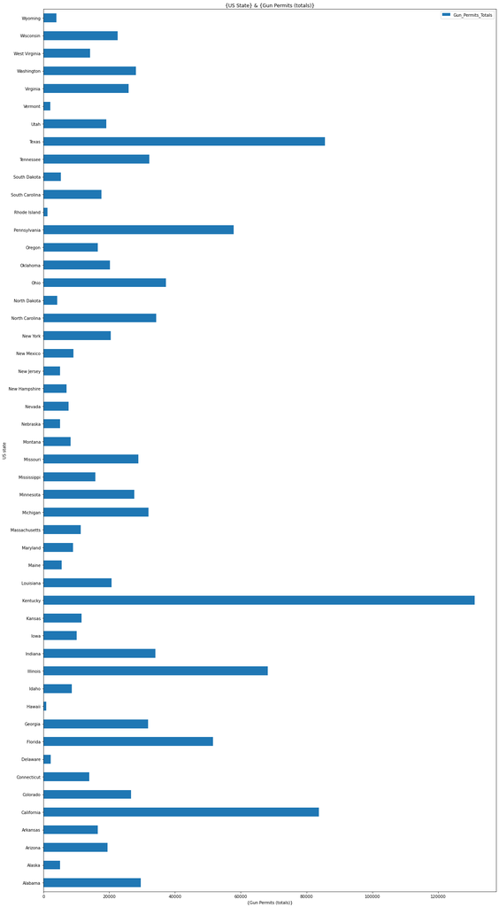

```python
final_df.plot(x='US_State', y= 'Gun_Permits_Totals',kind = 'barh',figsize=(20, 40))
plt.title('{US State} & {Gun Permits (totals)}')
plt.ylabel('US state')
plt.xlabel('{Gun Permits (totals)}')
```

US States and Gun Permits (totals)

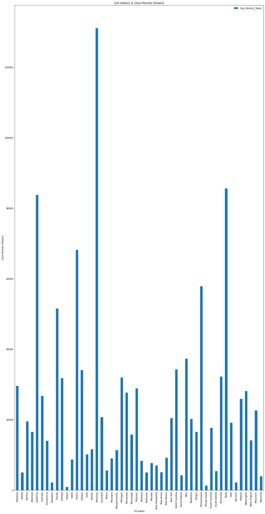

```python
final_df.plot(x='US_State', y= 'Gun_Permits_Totals', kind = 'bar',figsize=(20, 40))
plt.title('{US States} & {Gun Permits (totals)}')
plt.ylabel('{Gun Permits (totals)}')
plt.xlabel('US states')
```

Kentucky state has the highest Gun Permits (Gun_Permits_Totals)

## US States & State Population@2016

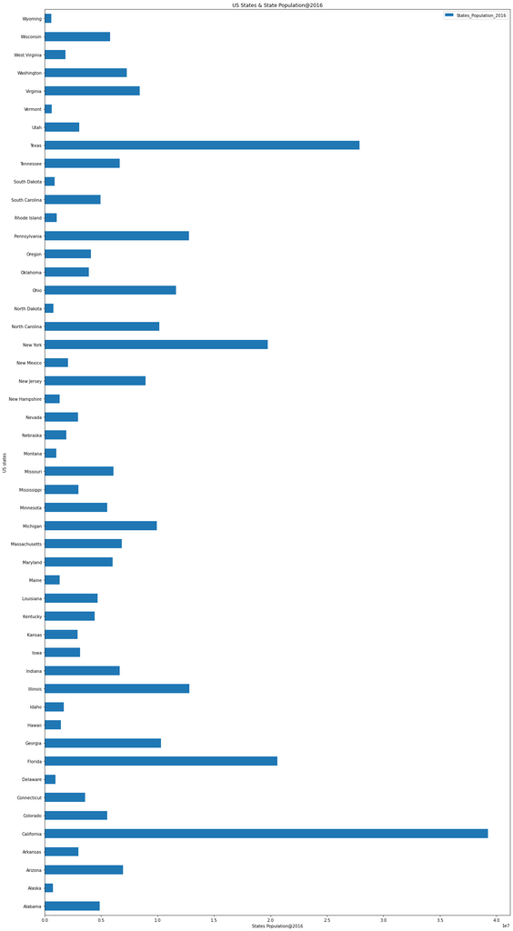

```python
final_df.plot(x='US_State', y= 'States_Population_2016',kind = 'barh',figsize=(20, 40))
plt.title('US States & State Population@2016')
plt.ylabel('US states')
plt.xlabel('States Population@2016')
```

US States & State Population@2016

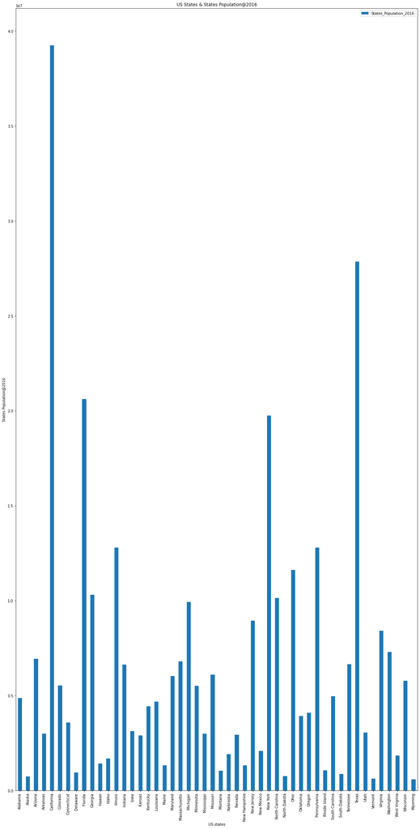

```python
final_df.plot(x='US_State', y= 'States_Population_2016', kind = 'bar',figsize=(20, 40))
plt.title('US States & States Population@2016')
plt.ylabel('States Population@2016')
plt.xlabel('US states')
```

Calfornia state has the heighest populations (States_Population_2016)

## US States & States Population@2010

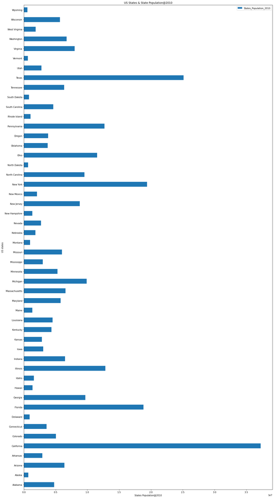

```python
final_df.plot(x='US_State', y= 'States_Population_2010',kind = 'barh',figsize=(20, 40))
plt.title('US States & State Population@2010')
plt.ylabel('US states')
plt.xlabel('States Population@2010')
```

US States & States Population@2010

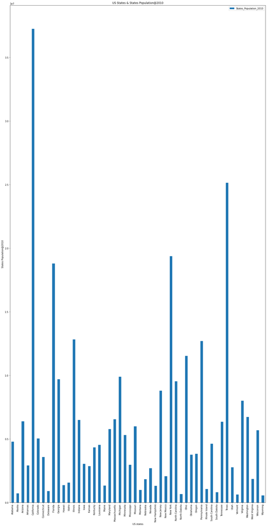

```python
final_df.plot(x='US_State', y= 'States_Population_2010', kind = 'bar',figsize=(20, 40))
plt.title('US States & States Population@2010')
plt.ylabel('States Population@2010')
plt.xlabel('US states')
```

Calfornia state has the heighest populations (States_Population_2010 )

## Relationship between increase in population growth and increase in Gun Permits

Rescaling Population to show trend inrelevat to the scale of Gun_Permits_Totals

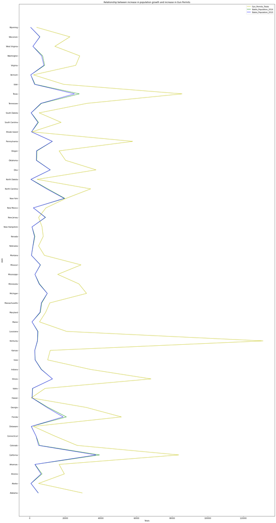

```python
# Relationship between increase in population growth and increase in Gun Permits

y  = final_df['US_State']
x1 = final_df['Gun_Permits_Totals']
x2 = final_df['States_Population_2016']
x3 = final_df['States_Population_2010']
# Rescaling Population to show trend inrelevat to the scale of Gun_Permits_Totals
x2/=1000
x3/=1000
fig = plt.figure(figsize=(20, 40))
ax = fig.add_axes([0,0,1,1])
l1 = ax.plot(x1,y,'y-') # solid line with yellow colour and square marker
l2 = ax.plot(x2,y,'g-') # dash line with green colour and circle marker
l3 = ax.plot(x3,y,'b-') # solid line with yellow colour and square marker
ax.legend(labels = ('Gun_Permits_Totals', 'States_Population_2016', 'States_Population_2010'), loc = 'upper right') # legend placed at lower right
ax.set_title('Relationship between increase in population growth and increase in Gun Permits')
ax.set_xlabel('Totals')
ax.set_ylabel('state')
```

Gun permits corelate to population

## Conclusions

> Although Kentucky state has the highest Gun Permits (Gun_Permits_Totals) and Calfornia state has the heighest populations (States_Population_2016 & States_Population_2010)

> But the overall picture illustrate that the Gun permits corelate to population